# BCB420 Computational System Biology

Assignment 2: Differential Gene expression and Preliminary ORA

Yuxi Zhu

2025-03-11

# A2 Wiki

[Yuxi Zhu GitHub Wiki](https://github.com/bcb420-2025/Yuxi_Zhu/wiki/Entry-9:-A2-Differential-Gene-expression-and-Preliminary-ORA)

The libraries used for this analysis are [1–7]:

```r
library(edgeR)
library(ComplexHeatmap)
library(circlize)
library(ggplot2)
library(knitr)
library(dplyr)
library(limma)
library(gprofiler2)
```

# Introduction

Pancreatic ductal adenocarcinoma (PDAC) is one of most deadly cancer with low five year survival rate. In this analysis, I will be looking at specifically RNA seq expression of macrophages with and without PDAC cancer-associated fibroblasts (CAFs) and the expression of macrophages with CAFs and with CAFs and FOLFIRINOX, which can infer information on intricate relationship between PDAC CAF and FOLFIRINOX and whether how FOLFIRINOX could modify the effect of CAF on PDAC patients [8].

### Dataset Used

Previous, I conducted data exploration on the my dataset of interest (GSE226448). After data cleaning to the original raw counts, I mapped the genes to HUGO symbols and applied normalization using edgeR package [1]. The coverage of the dataset went from 60660 to 13121 genes. The distribution of the dataset after normalization follows roughly negative binomial distribution, which is required desired for edgeR’s implementation of downstream analysis.

```r
file_path <- file.path(getwd(), "GSE226448", "GSE226448_normalized_filtered_counts.txt") # from output of A1
normalized_data <- read.table(file_path, header = TRUE, sep = "\t", row.names = 1, check.names = FALSE)
normalized_matrix <- as.matrix(normalized_data)
normalized_matrix_num <- matrix(as.numeric(normalized_matrix),
                                nrow = nrow(normalized_matrix),
                                ncol = ncol(normalized_matrix),
                                dimnames = dimnames(normalized_matrix))
kable(normalized_matrix_num[1:5, 1:5], format="html")
```

|  | M2-CAF_CTRL_rep1 | M2-CAF_CTRL_rep2 | M2-CAF_CTRL_rep3 | M2-CAF_FOLFI_rep1 | M2-CAF_FOLFI_rep2 |
| --- | --- | --- | --- | --- | --- |
| DPM1 | 17.626987 | 15.208069 | 20.434383 | 16.888989 | 17.708892 |
| SCYL3 | 7.173314 | 6.373970 | 6.405956 | 7.629946 | 8.062585 |
| FIRRM | 1.798269 | 1.938283 | 2.433031 | 2.062148 | 1.511735 |
| FGR | 337.363133 | 354.948135 | 330.245501 | 342.460846 | 345.071446 |
| CFH | 2.667761 | 3.280172 | 3.557153 | 3.051978 | 3.689353 |

From Figure 1, we can see the distribution of the RNA seq reads are smooth and no spread out, which is expected in normalized RNA seq data. The boxplot, as shown in figure 2 shows that the median is already roughly centered for the normalized RNA seq data.

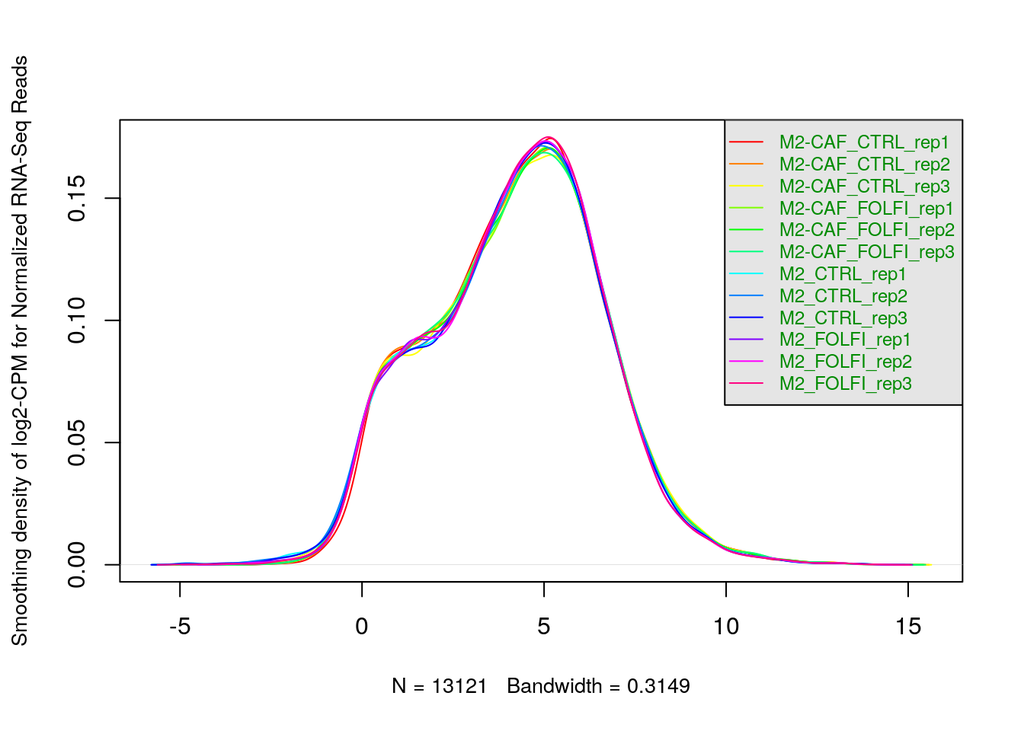

Figure 1: Distribution of the normalized gene read counts for all 12 samples.

```r
data2plot <- log2(normalized_matrix_num)
counts_density <- apply(log2(normalized_matrix_num), 2, density)
xlim <- 0; ylim <- 0
for (i in 1:length(counts_density)) {
xlim <- range(c(xlim, counts_density[[i]]$x));
ylim <- range(c(ylim, counts_density[[i]]$y))
}
cols <- rainbow(length(counts_density))
ltys <- rep(1, length(counts_density))
plot(counts_density[[1]], xlim=xlim, ylim=ylim, type="n",
ylab="Smoothing density of log2-CPM for Normalized RNA-Seq Reads",
main="", cex.lab = 0.85)
for (i in 1:length(counts_density))
lines(counts_density[[i]], col=cols[i], lty=ltys[i])
legend("topright", colnames(data2plot),
col=cols, lty=ltys, cex=0.75,
border ="blue", text.col = "green4",
merge = TRUE, bg = "gray90")
```

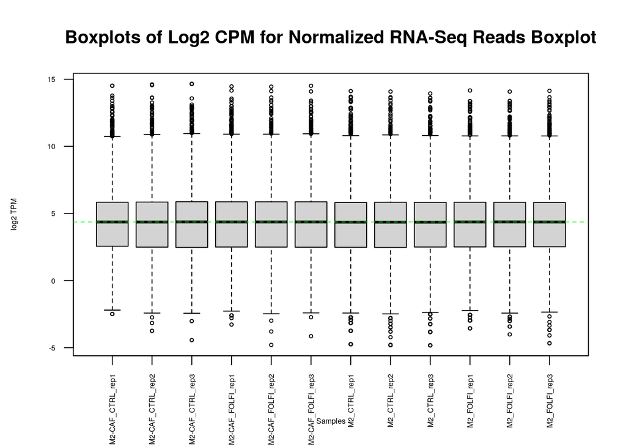

Figure 2: Boxplot of Distribution of the normalized gene read counts across all 12 samples.

```r
boxplot(data2plot, xlab = "Samples", ylab = "log2 TPM",
las = 2, cex = 0.5, cex.lab = 0.5,
cex.axis = 0.5, main = "Boxplots of Log2 CPM for Normalized RNA-Seq Reads Boxplot")
abline(h = median(apply(data2plot, 2, median)),
col = "green", lwd = 0.6, lty = "dashed")
```

### Data Separation

As seen in the MDS plot in Figure 3, the RNASeq data can be cleanly seperated by the four sample groups, where the replicates from sample groups are clustered closely together. This suggests that the four sample groups should be used as factors in the differential expression model.

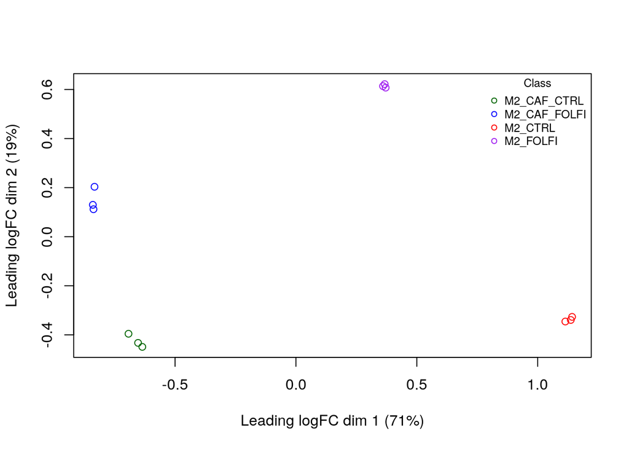

Figure 3: MDS plot of RNASeq data coloured by Sample Group. M2 macrophage samples are coloured as red; M2 macrophage treated FOLFIRINOX samples are coloured as purple; M2 macrophages co-cultured CAF are coloured as green and M2 macrophages co-cultured CAF and treated FOLFIRINOX are coloured as blue. This code adapted from BCB420 lecture.

```r
sample_names <- colnames(normalized_matrix_num)
groups <- factor(gsub("-", "_", gsub("_rep[0-9]+", "", sample_names)))
dge <- DGEList(counts = normalized_matrix_num, group = groups)
plotMDS(dge, labels=NULL, pch = 1,
               col = c("darkgreen","blue", "red", "purple")[factor(groups)])
legend("topright",
       legend=levels(factor(groups)),
       pch=c(1), col= c("darkgreen","blue","red", "purple"),title="Class",
       bty = 'n', cex = 0.75)
```

# 1 Differential Gene Expression Analysis

Since the dataset is already filtered and normalized from previous analysis using edgeR, the dataset will be used directly for differential expression analysis. In this analysis, the differential expression between M2 macrophages and M2 macrophages co-cultured with CAFs and the one between M2 macrophages co-cultured with CAFs and M2 macrophages with FOLFIRINOX treatment co-cultured with CAFs will be closely analyzed. The genes of interest are the 10 differentially expressed genes that are upregulated when adding CAFs to the control group and downregulated when you add CAFs under FOLFIRINOX treatment and vice versa: SLC40A1, METTL27, CCDC152, SELENOP, NLRP1, SHE, GPR155, SYNPO, GOS2 and LAD1, as reported in the paper [8]. As reported in the paper, their expression seems to be completely switch under the presence or absence of FOLFIRINOX [8].

Note: Since same code will be ran twice, I will use functions to simplify that.

```r
model_design <- model.matrix(~ 0 + groups)
colnames(model_design) <- levels(groups)
dge <- estimateDisp(dge, model_design)
contrast_matrix <- makeContrasts(
  M2_vs_M2CAF = M2_CAF_CTRL - M2_CTRL,
  M2_vs_M2FOLFIRINOX =  M2_FOLFI - M2_CTRL,
  M2FOLFIRINOX_vs_M2CAFFOLFIRINOX = M2_CAF_FOLFI - M2_FOLFI,
  M2CAF_vs_M2CAFFOLFIRINOX = M2_CAF_FOLFI - M2_CAF_CTRL,
  levels = model_design
)
perform_de_analysis <- function(fit, contrast_param) {
    # Raw p values
    de_results <- glmQLFTest(fit, contrast = contrast_matrix[, contrast_param])
    # Multiple hypothesis testing
    de_hits <- topTags(de_results, sort.by = "PValue", adjust.method = "fdr", n=nrow(normalized_matrix_num))
    de_genes <- rownames(de_hits$table[which(de_hits$table$FDR < 0.05 & abs(de_hits$table$logFC) > 1), ])
    up_reg_genes <- rownames(de_hits$table[which(de_hits$table$FDR < 0.05 & de_hits$table$logFC > 1), ])
    down_reg_genes <- rownames(de_hits$table[which(de_hits$table$FDR < 0.05 & de_hits$table$logFC < -1), ])
    result_df <- de_hits$table
    return(list(results_table = result_df))
}

generate_volcano_plot <- function(de_results, cus_title) {
  results_df <- de_results$results_table
  results_df$significance <- "ns"  # Default: Not significant
  results_df$significance[results_df$FDR < 0.05 & abs(results_df$logFC) > 1] <- "Significant"
  highlighted_genes <- c("SLC40A1", "METTL27", "CCDC152", "SELENOP", "NLRP1",
                          "SHE", "GPR155", "SYNPO", "GOS2", "LAD1")
  results_df$highlight <- ifelse(rownames(results_df) %in% highlighted_genes, "Highlighted", "Not Highlighted")
  upregulated_count <- sum(results_df$FDR < 0.05 & results_df$logFC > 1)
  downregulated_count <- sum(results_df$FDR < 0.05 & results_df$logFC < -1)
  total_DE_count <- sum(results_df$FDR < 0.05)

  highlighted_df <- subset(results_df, highlight == "Highlighted")
# Create Volcano Plot
  ggplot(results_df, aes(x = logFC, y = -log10(FDR), color = significance)) +
    geom_point(alpha = 0.6) +  # Plot all genes
    geom_point(data = highlighted_df,
               aes(x = logFC, y = -log10(FDR)),
               color = "red", size = 3) +  # Highlight specific genes
    geom_text(data = highlighted_df,
              aes(label = rownames(highlighted_df)),
              color = "red", vjust = -1, hjust = 0.5, size = 4) +  # Label highlighted genes
    scale_color_manual(values = c("gray", "blue")) +  # Define colors for significance
    theme_minimal() +
    labs(title = cus_title,
         x = "Log2 Fold Change", y = "-Log10 FDR") +
    theme(legend.position = "none") +
    # Add annotation showing number of DE genes
    annotate("text", x = min(results_df$logFC), y = max(-log10(results_df$FDR)) * 0.9,
             label = paste("DE genes:", total_DE_count,
                           "\nUpregulated:", upregulated_count,
                           "\nDownregulated:", downregulated_count),
             color = "black", size = 4, hjust = 0.2)
}
```

### 1a. Differential Expression Between M2 macrophages and M2 macrophages co-cultured with CAFs

By applying a threhold of p value less than 0.05, 3432 genes are significantly differentially expressed. Applying a multiple hypothesis testing method, specifically False Discovery Rate (FDR) method, 2437 genes passed correction and are significantly differentially expressed as shown in figure 4. FDR is a good choice for multiple hypothesis testing as it controls the proportion of false positives while also identify differentially expressed genes as it is less stringent and conservative compared to the Bonferroni correction. Similiar to the article, using the threshold of FDR adjusted p value less than 0.05 and log2 fold change of greater than 1 or less than -1 , 419 genes are upregulated and 304 genes are downregulated. As for the gene of interests, only 8 out of 10 of them are found in my dataset possibly due to them being filtered out during the preprocessing step. SYNPO and LAD1 is down-regulated when adding CAFs to macrophages and other 6 genes seems to be up regulated, which is consistent to the results in the paper.

```r
fit <- glmQLFit(dge, model_design)
M2_vs_M2CAF_DE <- perform_de_analysis(fit, "M2_vs_M2CAF")
nrow(M2_vs_M2CAF_DE$results_table[M2_vs_M2CAF_DE$results_table$PValue < 0.05,])
```

```
## [1] 3432
```

```r
nrow(M2_vs_M2CAF_DE$results_table[M2_vs_M2CAF_DE$results_table$FDR < 0.05,])
```

```
## [1] 2437
```

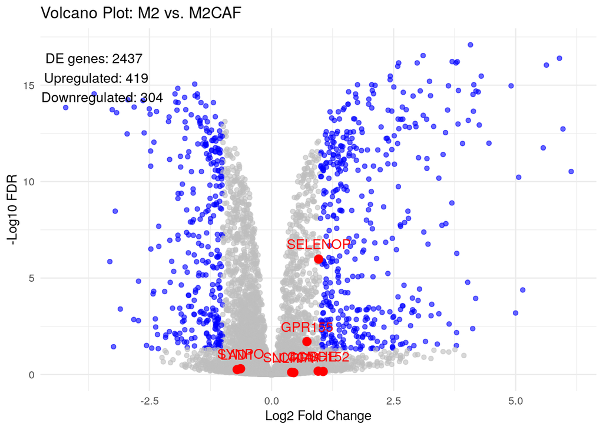

Figure 4: Volcano plot comparing RNA-seq data between M2 macrophages and M2 macrophages co-cultured with CAFs, where the gene of interests are highlighted with the red dots.

```r
M2_vs_M2CAF_de_genes <- M2_vs_M2CAF_DE$all_DE_genes
M2_vs_M2CAF_result_df <- M2_vs_M2CAF_DE$results_table
generate_volcano_plot(M2_vs_M2CAF_DE, "Volcano Plot: M2 vs. M2CAF")
```

### 1b Differential Expression Between M2 macrophages co-cultured with CAFs and M2 macrophages co-cultured with CAFs and treated with FOLFIRINOX

Using the same workflow as above, applying a threhold of p value less than 0.05 gives 1030 significantly differentially expressed genes. 382 genes passed correction and are significantly differentially expressed. Using the threshold of FDR adjusted p value less than 0.05 and log2 fold change of greater than 1 or less than -1, 44 genes are upregulated and 12 genes are downregulated. As for the 8 gene of interests, SYNPO, LAD1,CCDC152,GPR155 are down-regulated and SHE, SLC40A1, SELENO1 and NLR1 are up-regulated. CCDC152 and GPR155 were previously up-regulated when adding CAF to control macrophages and it is now down-regulated.

```r
M2CAF_vs_M2CAFFOLFIRINOX_DE <- perform_de_analysis(fit, "M2CAF_vs_M2CAFFOLFIRINOX")
nrow(M2CAF_vs_M2CAFFOLFIRINOX_DE$results_table[M2CAF_vs_M2CAFFOLFIRINOX_DE$results_table$PValue < 0.05,])
```

```
## [1] 1030
```

```r
nrow(M2CAF_vs_M2CAFFOLFIRINOX_DE$results_table[M2CAF_vs_M2CAFFOLFIRINOX_DE$results_table$FDR < 0.05,])
```

```
## [1] 382
```

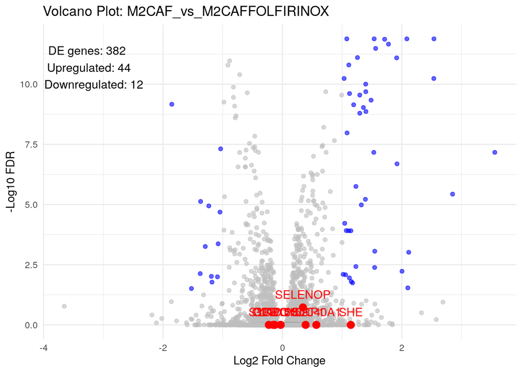

Figure 5: Volcano plot comparing RNA-seq data between M2 macrophages co-cultured with CAFs and M2 macrophages co-cultured with CAFs and treated with FOLFIRINOX

```r
generate_volcano_plot(M2CAF_vs_M2CAFFOLFIRINOX_DE, "Volcano Plot: M2CAF_vs_M2CAFFOLFIRINOX")
```

### 1c Differential Expression Analyis Using Heatmaps

```r
sample_groups <-gsub("-", "_", gsub("_rep[0-9]+", "", colnames(normalized_matrix_num)))
generate_heatmap <- function(de_results, title, sample_subset) {
    # Extract significant DE genes
    top_genes <- rownames(de_results$results_table)[de_results$results_table$FDR < 0.05]

    # Subset normalized matrix for selected genes AND relevant samples
    normalized_matrix_hits <- normalized_matrix_num[rownames(normalized_matrix_num) %in% top_genes, sample_subset]

    # Scale the data
    normalized_matrix_hits <- t(scale(t(normalized_matrix_hits)))

    # Define colors for sample annotations
    unique_samples <- unique(colnames(normalized_matrix_hits))
    unique_samples_colour <- rainbow(n=length(unique_samples))
    names(unique_samples_colour) <- unique_samples

    sample_groups <- gsub("-", "_", gsub("_rep[0-9]+", "", colnames(normalized_matrix_hits)))
    unique_groups <- unique(sample_groups)
    unique_groups_colour <- rainbow(n=length(unique_groups))
    names(unique_groups_colour) <- unique_groups

    # Define heatmap color scale
    heatmap_col <- colorRamp2(c(min(normalized_matrix_hits), 0, max(normalized_matrix_hits)), c("blue", "white", "red"))

    # Sample annotation
    hat_pat <- HeatmapAnnotation(df = data.frame(samples = colnames(normalized_matrix_hits),
                                                 groups = sample_groups),
                                 col = list(samples = unique_samples_colour,
                                            groups = unique_groups_colour),
                                 show_legend = TRUE)

    # Generate heatmap
    h <- Heatmap(as.matrix(normalized_matrix_hits),
            top_annotation = hat_pat,
            cluster_rows = TRUE,
            cluster_columns = TRUE,
            show_row_dend = TRUE,
            show_column_dend = TRUE,
            col = heatmap_col,
            show_column_names = FALSE,
            show_row_names = FALSE,
            show_heatmap_legend = TRUE,
            use_raster = FALSE,
            column_title = title)
    return(h)
}
# Define sample subsets for each pairwise comparison
samples_M2_vs_M2CAF <- colnames(normalized_matrix_num)[sample_groups %in% c("M2_CTRL", "M2_CAF_CTRL")]
samples_M2CAF_vs_M2CAFFOLFIRINOX <- colnames(normalized_matrix_num)[sample_groups %in% c("M2_CAF_CTRL", "M2_CAF_FOLFI")]
```

Two heatmaps are used to visualize the expression values of the top differentially expressed gene (where FDR < 0.05) from the analysis between M2 macrophages and M2 macrophages co-cultured with CAFs as shown in figure 6 and the analysis between M2 macrophages co-cultured with CAFs and M2 macrophages co-cultured with CAFs and treated with FOLFIRINOX. In both heatmaps, the samples from the same condition or group seems to be clustered together, indicating that the gene expression profile is consistent within each condition and the selected DE genes successfully differentiate between conditions. The clustering pattern support the validity of differential expression analysis. Both heatmaps, especially for figure 7, show clear clustering of genes with groups of distinct genes showing similar expression pattern across samples under same conditions, suggesting co-expression and possibly the involvement in the same pathway. Further enrichment analysis can be used to validate this hypothesis. We can also see that some cluster of genes are up-regulated in 1 condition as shown in red and some are down-regulated as shown in blue.

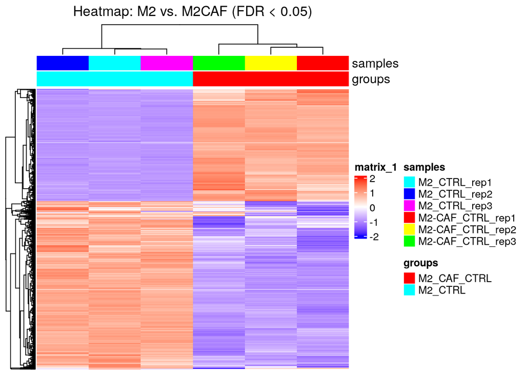

Figure 6: Heatmap comparing RNA-seq data between M2 macrophages and M2 macrophages co-cultured with CAFs

```r
heatmap_M2_vs_M2CAF <- generate_heatmap(M2_vs_M2CAF_DE, "Heatmap: M2 vs. M2CAF (FDR < 0.05)", samples_M2_vs_M2CAF)
heatmap_M2_vs_M2CAF
```

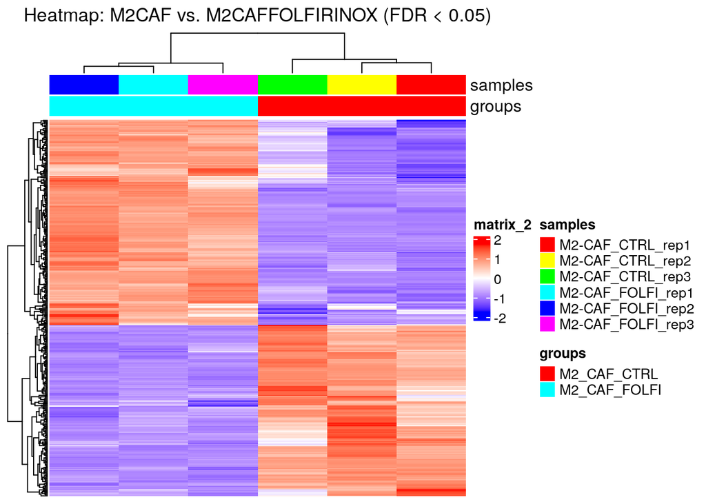

Figure 7: Heatmap comparing RNA-seq data between M2 macrophages co-cultured with CAFs and M2 macrophages co-cultured with CAFs and treated with FOLFIRINOX

```r
heatmap_M2CAF_vs_M2CAFFOLFIRINOX <- generate_heatmap(M2CAF_vs_M2CAFFOLFIRINOX_DE, "Heatmap: M2CAF vs. M2CAFFOLFIRINOX (FDR < 0.05)", samples_M2CAF_vs_M2CAFFOLFIRINOX)
heatmap_M2CAF_vs_M2CAFFOLFIRINOX
```

# 2 Thresholded over-representation analysis

Since heatmap comparing RNA-seq data between M2 macrophages co-cultured with CAFs and M2 macrophages co-cultured with CAFs and treated with FOLFIRINOX present clear clustering of genes that have distinct and opposite expression pattern across two different conditions, over-representation analysis(ORA) is conducted using g:Profiler on this dataset [2]. ORA evaluates whether some gene sets are overly represented in the given gene list wihtout requiring a ranked list or a full list of genes. Since we are only looking at part of the genes with some threshold applied, ORA with g:profiler will be the best choice. FDR corrections are applied to each g:profiler query and only the significant gene sets are return.

Additionally, the analysis used Gene Ontology (GO:BP), Reactome (REAC), and WikiPathways (WP) as annotation source [9–12]. Association of genes to GO:BP can describe molecular function, biological processes and cellular components. REAC can capture molecular details of biological pathways and process. WP provides community-driven knowledge for biological pathways. The three sources are commonly recommended as the source and can give comprehensive view of the pathways enriched in the given gene set.

```r
result_df <- M2CAF_vs_M2CAFFOLFIRINOX_DE$results_table
up_reg_genes <- rownames(result_df)[which(result_df$logFC > 1 & result_df$FDR < 0.05)]
down_reg_genes <- rownames(result_df)[which(result_df$logFC < 1 & result_df$FDR < 0.05)]
all_de_genes <- rownames(result_df)[which(result_df$FDR < 0.05)]
all_de_results <- gost(
  all_de_genes,
  significant=TRUE,
  exclude_iea=TRUE,
  ordered_query = FALSE,
  organism = "hsapiens",
  correction_method ="fdr",
  source = c("GO:BP", "REAC", "WP")
)
up_results <- gost(
  query=up_reg_genes,
  significant=TRUE,
  exclude_iea=TRUE,
  ordered_query = FALSE,
  organism = "hsapiens",
  correction_method ="fdr",
  source = c("GO:BP", "REAC", "WP")
)
down_results <- gost(
  down_reg_genes,
  significant=TRUE,
  exclude_iea=TRUE,
  ordered_query = FALSE,
  organism = "hsapiens",
  correction_method ="fdr",
  source = c("GO:BP", "REAC", "WP")
)
```

The analysis is performed using the latest g:profiler annotation version Ensembl 112 for gene mapping and functional annotations (as shown from e112_eg59_p19_25aa4782).

```r
up_results$meta$version
```

```
## [1] "e112_eg59_p19_25aa4782"
```

```r
down_results$meta$version
```

```
## [1] "e112_eg59_p19_25aa4782"
```

```r
all_de_results$meta$version
```

```
## [1] "e112_eg59_p19_25aa4782"
```

### 2a All DE Genes

For all differential expressed genes with fdr < 0.05, 1217 gene sets are siginificantly enriched, with 1023 gene sets from GO:BP, 134 from REAC and 60 from WP.

```r
all_de_enrich <- as.data.frame(all_de_results$result)
nrow(all_de_enrich)
```

```
## [1] 1217
```

```r
all_de_enrich <- all_de_enrich %>% dplyr::select(p_value, term_id, source, term_name) %>% arrange(p_value)
kable(all_de_enrich %>% group_by(source) %>% count(), format="html")
```

| source | n |
| --- | --- |
| GO:BP | 1023 |
| REAC | 134 |
| WP | 60 |

The five most enriched pathways sort the most significant p values are: response to stress, response to stimulus, Neutrophil degranulation, cellular response to stimulus, Immune System.

```r
kable(head(all_de_enrich), format="html")
```

| p_value | term_id | source | term_name |
| --- | --- | --- | --- |
| 0 | GO:0006950 | GO:BP | response to stress |
| 0 | GO:0050896 | GO:BP | response to stimulus |
| 0 | REAC:R-HSA-6798695 | REAC | Neutrophil degranulation |
| 0 | GO:0051716 | GO:BP | cellular response to stimulus |
| 0 | REAC:R-HSA-168256 | REAC | Immune System |
| 0 | GO:0006954 | GO:BP | inflammatory response |

### 2b Up Regulated Gene

For up regulated genes as defined above, 283 gene sets are siginificantly enriched, with 215 gene sets from GO:BP, 16 from REAC and 52 from WP.

```r
up_enrich <- as.data.frame(up_results$result)
up_enrich <- up_enrich %>% dplyr::select(p_value, term_id, source, term_name) %>% arrange(p_value)
nrow(up_enrich)
```

```
## [1] 283
```

```r
kable(up_enrich %>% group_by(source) %>% count(), format="html")
```

| source | n |
| --- | --- |
| GO:BP | 215 |
| REAC | 16 |
| WP | 52 |

The five most enriched pathways sort the most significant p values are: p53 transcriptional gene network, Dcellular response to stress, DNA damage response, miRNA regulation of DNA damage response, and DNA damage response.

```r
up_enrich$term_name[1:5]
```

```
## [1] "p53 transcriptional gene network"
## [2] "cellular response to stress"
## [3] "DNA damage response"
## [4] "miRNA regulation of DNA damage response"
## [5] "DNA damage response"
```

```r
kable(head(up_enrich), format="html")
```

| p_value | term_id | source | term_name |
| --- | --- | --- | --- |
| 0e+00 | WP:WP4963 | WP | p53 transcriptional gene network |
| 0e+00 | GO:0033554 | GO:BP | cellular response to stress |
| 0e+00 | WP:WP707 | WP | DNA damage response |
| 0e+00 | WP:WP1530 | WP | miRNA regulation of DNA damage response |
| 2e-07 | GO:0006974 | GO:BP | DNA damage response |
| 8e-07 | GO:0006950 | GO:BP | response to stress |